# Beyond Canopy Coverage: Species Composition, Urban Forest Equity, and Neighborhood Health in Chicago

Paul Balea, Illinois Institute of Technology[^1]

Tomas Rebelatto, Illinois Institute of Technology[^2]

Spring 2026 SoReMo Fellowship Project Final Technical Report

[Back to journal](https://soremo.library.iit.edu)

# Abstract

# 1. Introduction

## 1.1 Urban trees and public health

Trees in urban areas have been shown to have various positive effects on public health. The connection has mostly been observed through canopy coverage. A denser urban forest increases canopy coverage, increasing overall shade and decreasing surface temperature. By observing differences in canopy coverage across neighborhoods of different demographics, McDonald, Biswas, Chakraborty, and others estimated that trees annually help avoid 632 ± 100 deaths in white neighborhoods and 442 ± 97 deaths annually in majority POC neighborhoods. This disparity can be attributed to a significant difference in tree canopy coverage between white neighborhoods and the majority POC neighborhoods [2]. This is significant to our research as there is a disparity in tree equity between neighborhoods in Chicago, which will be expanded on in the next section. Beyond heat-related complications, a denser urban forest can also be linked to a decrease in harmful fine particles such as (PM2·5), nitrogen dioxide (NO2), and tropospheric ozone (O3). A recent quantitative health impact assessment performed by Sicard, Pascu, Petrea, and others across 744 urban centres in 36 European countries estimated that for each five percentage point increase in tree canopy, 4,727 air pollution-related premature deaths could potentially be prevented annually across those cities [1]. Public health is not only concerned with physical health and mortality, however, as mental health is also a serious concern. The effect of canopy coverage on various mental health metrics has also been extensively studied. Canopy has been shown to have a positive impact in decreasing suicide attempts [19] and decreasing dementia rates [3]. Overall, prior research has indicated that higher canopy coverage can have positive effects on various public health metrics.

## 1.2 Chicago’s urban forest inequity

In 1934, the federal government set up the National Housing Act (NHA). This program was intended to encourage home ownership by offering low-cost loans. The risk that was associated with each of these loans was assessed, and neighborhoods in Chicago were split into four categories: A, B, C, and D. The Home Owners’ Loan Corporation (HOLC) was established the prior year to create security maps that labeled neighborhoods with these specific rankings. Race was explicitly used for the rankings, with A being deemed the safest, primarily white and US-born, newest structures, and D being deemed hazardous, mostly black and foreign-born people, with the oldest houses [5]. These assessments reflected racial assumptions rather than actual financial risk. On maps of the Chicago area, D neighborhoods were marked red, and this is where the term ‘redlining’ comes from.

Historical redlining has contributed to racial segregation and wealth disparities, which have shaped where public and private investment has been directed [6]. Redlined neighborhoods received reduced investment in green infrastructure over subsequent decades, and because urban canopy accumulates over time, these effects are still visible in the present landscape [7]. This pattern is evident nationally, as a 2021 study has found evidence of an association between worse historical HOLC grades and less green space in U.S. urban areas [6]. In Chicago, these neighborhoods still see the impacts of historic redlining, as A-ranked neighborhoods have about 27% more canopy coverage than D-ranked ones [5].

The Chicago Region Trees Initiative (CRTI) has extensively documented where canopy coverage is low, and the related challenges are amplified [8]. CRTI has developed maps of priority areas and conducted canopy assessments to improve equitable access to green spaces across Chicago. These maps are separated by neighborhood and ranked by the highest need for improved tree canopy, along with other variables such as surface temperature, air quality, and asthma risk [9]. There is a geographic concentration of low canopy coverage on Chicago’s South and West Sides, and our study aims to investigate how understanding species composition can help us better understand Chicago’s urban forest.

## 1.3 The species composition gap

Research on Chicago’s urban forest has identified that species composition is a key determinant of ecosystem service delivery in urban forests. Large trees have greater per-tree benefits when it comes to pollution removal, carbon storage, and carbon sequestration. Additionally, using long-lived and low-maintenance trees offers the opportunity to reduce pollutant emissions from planting, removal, and maintenance activities. Evergreen trees should be used for their particulate matter benefits and because they offer year-round benefits compared to deciduous trees that lose their leaves when dormant [10]. These findings suggest that species selection is an essential consideration and deserves more attention as a dimension of the urban forest, because species identity shapes ecological value and human health outcomes.

Native tree species support significantly greater biodiversity when compared to invasive and non-native species. A study that compared lepidopteran (butterflies and moths) use of native plants versus introduced species found that native plants supported approximately four times more lepidopteran species than introduced plants. When the comparison was restricted to ornamental plants, native plants supported fourteen to fifteen times more lepidopteran species than introduced ornamentals [11]. Native tree species anchor broader food webs by supporting insect communities that other wildlife depend on. Insect diversity is an important consideration in urban areas, where non-native ornamental plantings outnumber native species. The native versus non-native species composition of Chicago’s urban forest is poorly documented and is a gap that this study aims to begin addressing through IIT’s Alphawood Arboretum.

Beyond ecological value and ecosystem services, species composition may affect physical and mental health. Bratman et al. (2019) identify species composition and biodiversity as potential factors affecting mental health [12]. Clearer links exist between urban tree cover and physical health outcomes. A 2008 study by Lovasi et al. concluded that street trees were associated with a lower prevalence of early childhood asthma; however, the causal relationship at the individual level remains to be established [13]. More direct evidence comes from a study documenting the spread of the emerald ash borer, which found that counties that experienced a loss of trees due to the emerald ash borer had increased mortality rates related to both cardiovascular and lower respiratory illness [14].

Species composition has been understudied compared to canopy coverage quantity. This study aims to contribute evidence supporting greater consideration of species composition, using IIT’s Alphawood Arboretum as a proof-of-concept for what species-level analysis can reveal at the neighborhood level in Chicago.

## 1.4 Species data gap

The long-term goal of this project is to come to data-driven conclusions about the effects of specific species, tree attributes, and biodiversity levels on different physical and mental health metrics in Chicago. In order to achieve this, a large sample of tree plots across a variety of neighborhoods or census tracts is necessary. Currently, these plots do not exist outside of college campuses and smaller, wealthier neighborhoods. To work around this, this report focuses on finding ways to best describe the data that does exist. In terms of large-scale Chicago data, this is in the form of census tract health and socioeconomic data and overall canopy coverage. In terms of species-specific tree plot data, this report will focus on IIT’s Alphawood Arboretum.

## 1.5 Research questions

Prior research has contributed to finding the connection between canopy coverage and health benefits, and this study aims to extend these findings by incorporating species-level analysis. Our research will be driven by the following three questions:

1. Does tree canopy coverage predict neighborhood health outcomes across Chicago’s census tracts after controlling for environmental and socioeconomic factors?
2. Does neighborhood-scale species composition data exist at a resolution sufficient to test species-level hypotheses across Chicago’s urban forest?
3. What can the IIT Alphawood Arboretum reveal about the ecosystem service potential of species-specific urban plantings in a South Side neighborhood context?

# 2. Data and Methods

## 2.1 Data sources

Tree canopy coverage data were extracted from the CRTI. This dataset provides census-tract-level estimates of canopy coverage, vulnerability indices, surface temperatures, and air-toxin exposure for 801 census tracts. The CRTI priority scores are computed based on air toxin exposure, surface temperature, flood susceptibility, and social vulnerability. These data served as our primary source for urban tree canopy coverage in this analysis.

Chicago health outcome data were extracted from the CDC PLACES Local Data for Better Health, 2025 release. This dataset provides estimates for asthma, COPD, physical inactivity, mental health days, obesity, and depression at the census tract level. These data served as our primary source of neighborhood health outcome measures in this analysis.

Census tract boundary data were obtained from the US Census Bureau’s TIGER/Line Shapefiles, 2010 release. This dataset provides the boundaries for all 801 Chicago census tracts and was used to spatially join health, canopy, and socioeconomic data. Tract boundaries were matched based on a GEOID identifier.

Socioeconomic data were extracted from American Community Survey (ACS) 5-year estimate datasets, 2024 release. These datasets provided estimates about median income, poverty rate, education, and race/ethnicity at the census tract level in Chicago. These data were used as covariates to control for socioeconomic factors in the regression models.

Air quality data were obtained from the 2020 Chicago Air Quality and Health Index. This dataset provides air quality scores and percentile ranks for each census block group in the city. AQH scores were aggregated to the census tract level using population-weighted averaging prior to analysis.

Species-level tree inventory data were available for the Illinois Institute of Technology Alphawood Arboretum, located in the Douglas area (census tract 3510) on Chicago’s South Side. This inventory documents 1,442 established trees across 77 unique species, on IIT’s Mies campus. This dataset contained species name, common name, and diameter at breast height (DBH) measurement. These data were used for all analyses related to our case study of IIT’s Alphawood Arboretum.

A 2010 USDA Forest Service report [10] provided a table with pollution removal, carbon sequestration, and carbon storage estimates for trees based on their DBH class. These data were used to quantify the ecosystem service contributions of each tree species recorded in the IIT Alphawood Arboretum inventory.

## 2.2 Data integration

All datasets were merged at the census tract level using the GEOID identifier. The ACS GEOID values had prefixes, so those numbers had to be truncated so that they matched the format of the TIGER/Line dataset. AQH scores existed at the block group level, and multiple block groups exist in each census tract, so block group scores were weighted by population before averaging to the tract level. The final merged dataset contained 801 census tracts, 31 columns, covering all of Chicago.

To clean the IIT tree inventory, 201 trees with implausible or missing DBH values were excluded, which can be attributed to data entry errors. Only established trees were retained, excluding any saplings that were recently planted.

Of 801 tracts, 39 (4.9%) were excluded from the regression for missing values, most commonly in one or more health or socioeconomic variables, AQH score, or median income. These tracts were concentrated on Chicago’s South and West sides, the same areas exhibiting the highest health burden and lowest canopy coverage. The analytic sample therefore under-represents the highest-need neighborhoods. This may bias the socioeconomic coefficients, though the direction was not explored in this study. These tracts were retained in the descriptive mapping but not the regression or ranking.

## 2.3 Composite Health Index

Five health outcomes were combined into a composite Health Burden Index to capture shared variance among the outcomes and reduce dimensionality. Asthma, COPD, physical inactivity, mental health days, and obesity were the five outcomes used, with higher values indicating worse health outcomes. Depression was excluded from the index because it was positively correlated with median income (r = 0.348, p < 0.001) and education (r = 0.460, p < 0.001), suggesting that this reflects access to healthcare and diagnosis rates rather than underlying health burden.

All five variables were expressed as census tract-level prevalence percentages. Before PCA, variables were standardized using z-scores. PC1 is the Health Burden Index, which summarizes a tract’s health across all five health outcomes simultaneously. Higher values on the Health Burden Index indicate greater health burdens (poorer overall census tract health). PC1 captures 86.1% of the variance, meaning that this one number explains almost all the information contained in the five separate measures. All five variables load positively, meaning that PC1 represents a unified health burden.

To validate this methodology, the PCA index was compared with the z-score average of all five health variables. A high correlation of r = 1.000 between the two confirms that the index is robust.

## 2.4 Regression model structure

All regression models use census tracts as the unit of analysis. The composite Health Burden Index (PC1) is the primary response variable. Four progressive models were built rather than just running one model. This approach allows observation of how the canopy coefficient changes as additional factors are introduced. The models are as follows:

1. Bivariate — canopy only
2. +Environmental controls (AQH score, air toxins, surface temperature)
3. +Social vulnerability index
4. Full model + ACS socioeconomic controls (median income, poverty rate, educational attainment, percent Black residents, percent Hispanic residents)

Ordinary Least Squares regression was used because the response variable is continuous and the data were approximately normally distributed. The Breusch-Pagan test was used to test for heteroscedasticity, which means the variance of the residuals is not constant across predictors. Heteroscedasticity was identified in all four models, and to correct this, heteroscedasticity-robust standard errors (HC3) were applied. HC3 standard errors account for unequal residual variance and allow for more reliable inference.

For all predictors in Model 4, variance inflation factors (VIF) were computed, and most variables had a VIF below 5, except for the percentage of black residents (VIF = 8.73) and the percentage of Hispanic residents (VIF = 7.98). The results of this indicate that moderate collinearity exists between these two variables.

Consistent with the ecological fallacy, all of the results of this regression analysis represent tract-level ecological associations, and individual-level inferences cannot be drawn from this analysis. Moran’s I was computed to assess for spatial autocorrelation. A significant positive value (I = 0.291, p < 0.001) indicates that residual spatial autocorrelation remains after controlling for socioeconomic factors. A spatial regression model is recommended in any future work, and results should be interpreted under this known limitation.

## 2.5 Priority planting framework

To establish priority tracts, Health Burden Index scores were combined with canopy coverage data across all of the 762 census tracts with complete data. Tracts were ranked using a composite priority score, which was weighted equally between health burden rank and low canopy rank. This framework is intended to provide community organizations with evidence-based guidance on where targeted tree planting would have the greatest potential impact.

# 3. Results

## 3.1 Descriptive overview of Chicago’s urban forest and health outcomes

799 residential census tracts were analyzed to provide a better understanding of Chicago’s urban forest. The urban forest is characterized by a mean canopy coverage of 19.29%, a median of 18.79%, and a standard deviation of 7.84%. The lowest canopy tract is a census tract in the Edgewater area with a canopy coverage of 1.39%. Although Edgewater is a northside area, this specific census tract represents a dense high-rise residential area. The highest canopy tract is the Ohare residential area tract with a coverage of 69.04%.

CRTI’s priority tracts were also analyzed, and results showed that 312 tracts were classified as very high priority and 301 tracts were classified as high priority. CRTI’s analysis covered 782 of 799 residential tracts, because 17 tracts are missing rank values, but 78.4% of these were classified as high or very high priority. Very high priority tracts have a mean of 14.24% canopy coverage, whereas very low priority tracts have a mean canopy coverage of 39.54%. 73 tracts (9.3%) have canopy coverage below 10%. Areas of lower canopy coverage are concentrated in the downtown Chicago area, in and around the Loop neighborhood area. This represents the urban density and commercial land use in downtown Chicago.

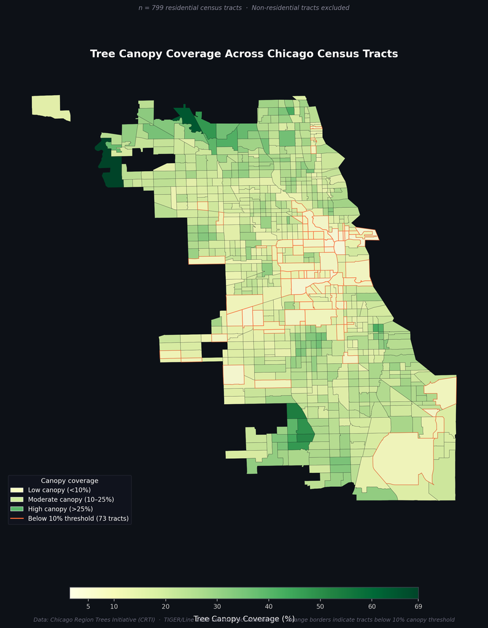

*Figure 1. Tree Canopy Coverage Across Chicago Census Tracts*

The five health outcome variables and citywide averages were asthma (10.52%), COPD (5.94%), physical inactivity (25.94%), mental health days (16.49%), and obesity (33.96%). The range of physical inactivity ranges from a minimum of 8.50% to 51.70%, which is the widest range of any of the health outcome variables. The wide range represents the substantial variation that the Health Burden Index is designed to capture.

[figure not shown]

*Figure 2: Health Burden Index across 782 residential census tracts in Chicago*

Areas of higher health burden are concentrated in Chicago’s south and west sides. This is consistent with the historical disinvestment that is discussed in section 1.2. The low canopy tracts in Chicago’s downtown do not correspond to high health burden. This suggests environmental and health inequity in Chicago’s South and West side, where there are elevated health burden scores.

## 3.2 Composite Health Burden Index - PCA results

PCA of the standardized health outcome variables yielded a first principal component (health burden index) that explains 86.1% of the variance. This confirms that a single component accurately represents the shared health burden across Chicago’s census tracts. All five health outcome variables load positively, ranging from 0.432 (asthma) to 0.470 (obesity), as shown in Figure 3. This represents a unified health burden dimension.

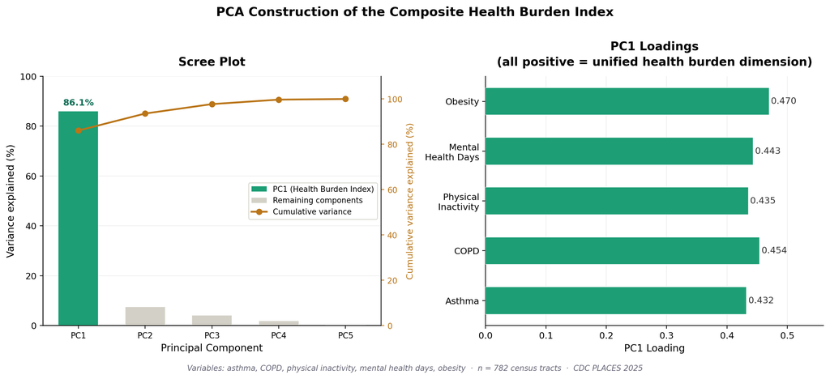

*Figure 3: PCA Construction of the Health Burden Index*

## 3.3 Regression analysis results

All four models are presented in Table 1, showing $R^2$, Adjusted $R^2$, canopy coefficient, and significance.

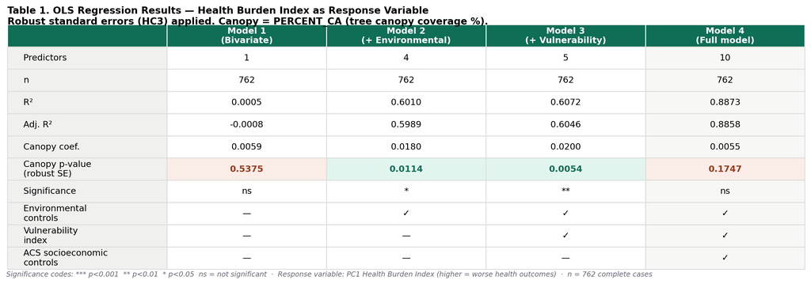

*Table 1: Regression results across four models*

Model 1 is the bivariate result, and canopy alone is not significant at the α = 0.05 level (p = 0.5375). Model 2 adds environmental controls (AQH score, air toxins, and surface temperature), and model 3 also adds the CRTI social vulnerability index. For these models, the canopy coefficient is positively and significantly associated with the composite health burden index, where model 2’s p-value is 0.0114 and model 3’s is 0.0054. This is not a causal relationship and represents confounding between the variables. Wealthier neighborhoods tend to have higher canopy coverage and better air quality, so once air quality is controlled, canopy coverage appears to have a positive association with health burden. Model 4 is the full model, and it adds poverty rate, educational attainment, and racial composition. In this model, the canopy coefficient is no longer significant (p = 0.1747).

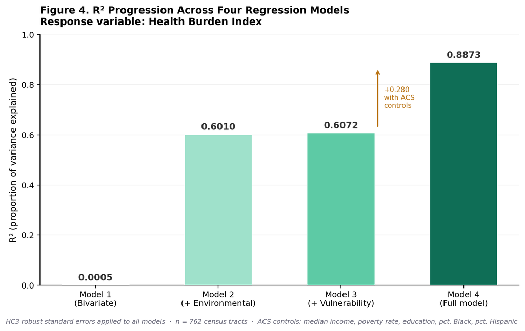

Figure 4

*Figure 4: Progression of $R^2$ through all four models*

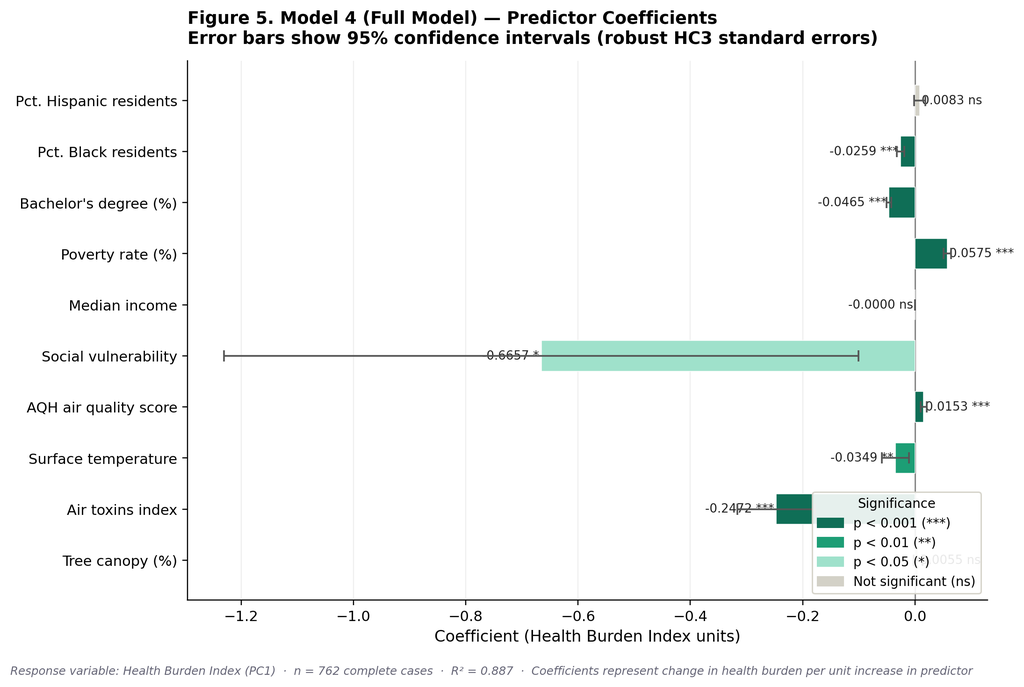

*Figure 5: Model 4 coefficient plot with 95% confidence intervals from robust standard errors*

## 3.4 Priority planting tracts

The priority tracts were identified using a formula that assigns 50% weight to the health burden rank and 50% to the canopy coverage rank across the 762 census tracts with complete data. The highest priority tracts based on this analysis are in the community areas, Armour Square, South Chicago, and Fuller Park. The top 10 priority census tracts have an average canopy coverage of 8.38% with health burden scores ranging from 2.949 to 6.06. Health burden scores are PCA-derived and are expressed as standard deviations away from the mean = 0. Priority planting is geographically concentrated in Chicago’s west and south sides, as illustrated in Figure 6.

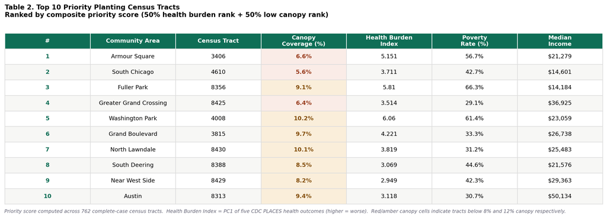

*Table 2: Top 10 priority planting census tracts*

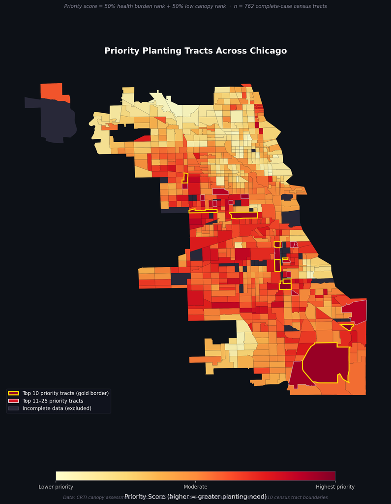

*Figure 6: The priority planting map of Chicago*

# 4. Discussion

## 4.1 Interpreting the canopy-health relationship result

Canopy coverage alone does not significantly predict neighborhood health outcomes in Chicago. When socioeconomic factors are controlled, the relationship between canopy coverage and composite health burden disappears. $R^2$ rose from near 0 in the bivariate model to 0.601 when environmental controls were introduced and jumped again to 0.887 when socioeconomic controls were introduced to the model. This shows that socioeconomic controls such as poverty rate, educational attainment, and race are dominant factors in health burden.

These results reinforce the importance of species composition as a research focus, instead of just tree coverage quantity. The null canopy result does not mean that trees are irrelevant to health, but instead shows that census-level canopy coverage data is too confounded and coarse to draw species-specific conclusions. Past research has linked street trees to lower asthma prevalence [13] and a loss of trees linked with increased cardiovascular and respiratory mortality [14]. With more precise data, further analyses can be conducted so that specific trees can be identified that have the greatest positive impact on health.

## 4.2 Priority planting framework and suggestions to community organizations

The priority planting framework suggests investment into priority areas that would see the biggest improvements in health burden and canopy coverage. The top ten priority tracts have been identified in Table 2, and some priority areas include Armour Square, South Chicago, Fuller Park, Greater Grand Crossing, and Washington Park. Based on the Alphawood Arboretum inventory, the Thornless Honeylocust is the dominant species, which also sequesters and stores the most carbon. Trees like this that have performed well in a South Side environment should be considered for further planting across priority census tracts, especially across the South Side.

Urban forestry best practices for protecting against pests suggest that an urban forest should contain no more than 10% of any single tree species, 20% of any single genus, and 30% of any single family [17]. The Thornless Honeylocust makes up 32% of the trees on IIT’s campus which is more than three times the suggested 10% species guideline as recommended by the 10/20/30 rule. Further planting in the Alphawood Arboretum should keep this figure in mind and should aim to increase biodiversity.

For targeted planting across Chicago, several actionable recommendations can be made. Prioritizing species that reach large DBH, have long lifespans, and require minimal maintenance will deliver the greatest long-term ecosystem benefits [10]. Additionally, high-benefit trees that have been successfully planted and maintained in certain geographic areas should be further utilized in areas with low canopy coverage and high health burden. In order to quantify benefits specific species bring, existing tree inventories and any future trees planted should be documented for further analysis

# 5. Alphawood Case Study

## 5.1 Methodology

To perform a standalone analysis on IIT’s Alphawood Arboretum, we needed to determine what was possible to analyze with our data, what aspects of the urban forestry we wanted to focus on, and which mathematical analysis methods would be necessary to achieve these objectives. Our objectives for the analysis were:

1. Observe species breakdown and quantify biodiversity
2. Estimate canopy coverage
3. Estimate carbon sequestration and storage
4. Estimate pollutant removal

In order to quantify biodiversity, we used Shannon’s Diversity Index $(H' = -\sum_i p_i \ln p_i)$, where $S$ represents species richness, and $pᵢ$ represents the proportional abundance of each species $i$. Pielou’s evenness $(J' = \frac{H'}{\ln(S)})$ was also calculated to decouple contributions of richness and evenness to overall diversity.

The arboretum’s ecosystem services were quantified using the i-Tree Eco v6.040 model [16], applied to field inventory data collected at Alphawood in 2026 [18].

i-Tree, an urban and rural forestry analysis assessment tool provided by the USDA Forest Service, was used to assess forest structure and quantify environmental effects due to Alphawood’s urban forest. To run the model, the arboretum dataset was input with columns for tree ID, DBH in inches, tree species scientific name, and latitude/longitude. Before running the analysis, the location for Chicago, Cook County, Illinois, was entered. The Midway Airport pollution and weather data collection centers were selected for the model to estimate location-specific pollution and air quality levels.

i-Tree utilizes species-specific equations to calculate dry biomass from provided DBH values. If no species-specific equation exists, the model falls back to a genus-level equation, then to a hardwood or conifer average. Open-grown urban trees tend to be less dense than forest trees, so their biomass was reduced by 20%. Biomass was then converted to carbon by multiplying by 0.5. In order to estimate sequestration, the i-Tree model added average annual diameter growth to the current diameter to estimate what the tree would store one year later, estimating annual carbon sequestration. The i-Tree model has the ability to calculate leaf area via crown dimensions and percentage of crown canopy missing. Since the Arboretum data did not contain this information, the model estimated it based on species and DBH values. This was used to estimate tree cover and leaf area values for each tree plot. Since tree crown health was also not measured, the model used a default 13% dieback, or 87% condition. This means that the growth rate and health of dead or dying trees would be overestimated, which must be taken into consideration in the analysis.

Using i-Tree’s hybrid big-leaf and multi-layer canopy deposition model, hourly tree-canopy resistance values were calculated for ozone, sulfur dioxide, and nitrogen dioxide. Carbon monoxide and particulate matter removal used average measured values from literature that were adjusted based on leaf phenology and leaf area, and a 50% resuspension rate of particles back into the atmosphere was incorporated in the particulate removal estimates.

i-Tree Eco also produces monetary valuations for pollution removal and carbon (pollution valued via avoided-damage/externality costs, carbon via a social-cost-of-carbon rate). These are model-generated estimates of societal avoided-damage value, not healthcare or public-spending savings, and are reported for context and not analyzed quantitatively.

It is important to address that these results are estimates dependent not only on the quality of the data collected, but also on the quality of weather and pollution data collection centers in the area. The nearest data collection center for both weather and pollution data was the Midway Airport location, which was labeled as “poor” quality by the i-Tree Eco software at the time of processing. Furthermore, the newest version of the software recommends inputting the crown measurements described earlier, which were not measured in the arboretum. The effects of these parameters will be discussed.

## 5.2 Results and Discussion

The Alphawood Arboretum contains 1643 tree plots across the campus, comprising 82 unique species. However, 201 of the 1643 plots had missing or implausible DBH values. After dropping those entries for the analysis, we are left with 1442 trees over 77 unique species. Of these 1442 plots, Thornless Honeylocusts made up 32.0% of the total, followed by Hawthorn, making up 11.0%, and Green Ash, 6.7% of the total.

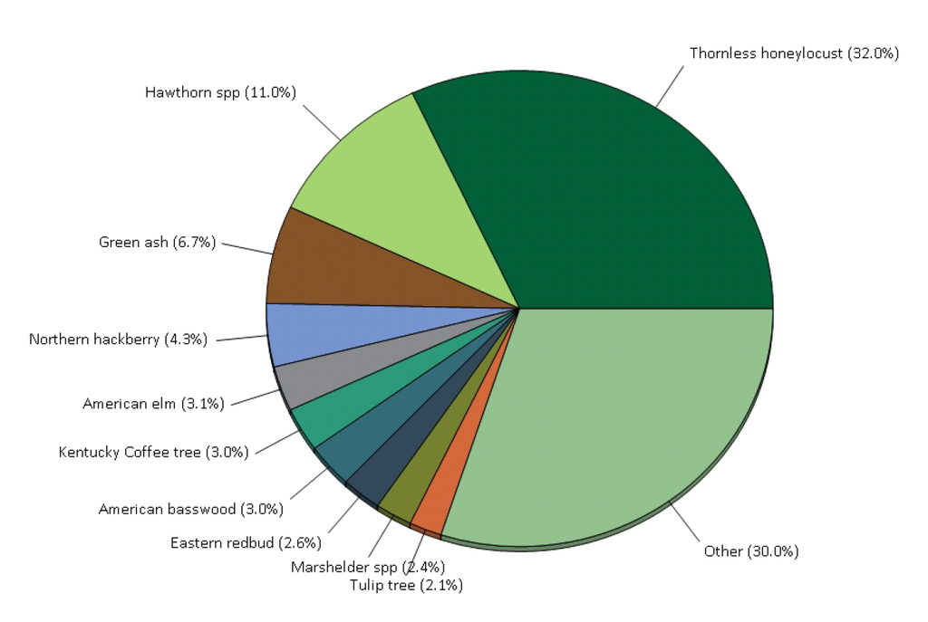

*Figure 7. Tree species composition in Alphawood*

With 77 species recorded, Alphawood has a reasonably diverse species palette for an urban forest. However, species richness alone doesn’t effectively quantify the arboretum’s diversity.

Species biodiversity was quantified using $H’$, giving a value of:

$H’ = 2.98$

For $S = 77$ species, the maximum $H’$ value is given by:

$H’_{max}= ln(S) = ln(77) = 4.34$

Using Pielou’s Evenness $(J’)$ to standardize:

$J’ = \frac{H’}{ln(S)} = 0.68$

The Shannon index $(H’)$ value of 2.98 out of a theoretical maximum of 4.34 indicates moderate to good diversity. The forest is neither a monoculture nor a fully balanced mix of species. This result is expected, as Thornless Honeylocust alone makes up 32% of all plotted trees. The $J’$ value of 0.68 out of a maximum of 1.0 confirms this picture. The forest is moderately even, meaning tree abundance is reasonably spread across species, but not uniformly so.

Using the USDA i-Tree Eco software with the data and parameters described in the methodology section, tree coverage, carbon storage and sequestration, and pollutant removal rates were estimated. From the 1442 plots, the model estimated approximately 25.02 acres or 101,252.35 $m^{2}$ of canopy coverage across the campus. Before processing each plot and its DBH values, the overall breakdown of the percentage of trees in each DBH range was calculated and plotted in Figure 8.

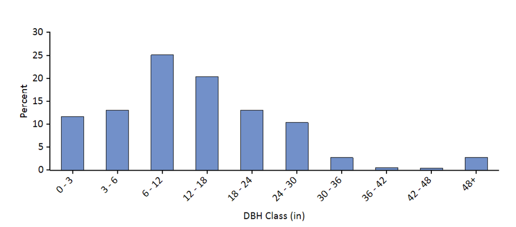

*Figure 8. Percent of tree population by diameter class (DBH - stem diameter at 4.5 feet)*

The breakdown of the percent of the tree population by diameter class was roughly unimodal, with the most populous classes being 6-12” and 12-18”, accounting for ~25% and ~20% of the total, respectively.

The most dominant species in terms of leaf area is the Thornless Honeylocust, accounting for 30.7% of leaf area and 32.0% of the overall population. Hawthorn is second with 15.2% leaf area and 11.0% of the population, followed by Green Ash with 10.2% leaf area with 6.7% of the population. Based on the percent share of leaf area and population, the model calculated importance values (IV) for each species. The top 10 most important species in Alphawood are listed in *Table 3*.

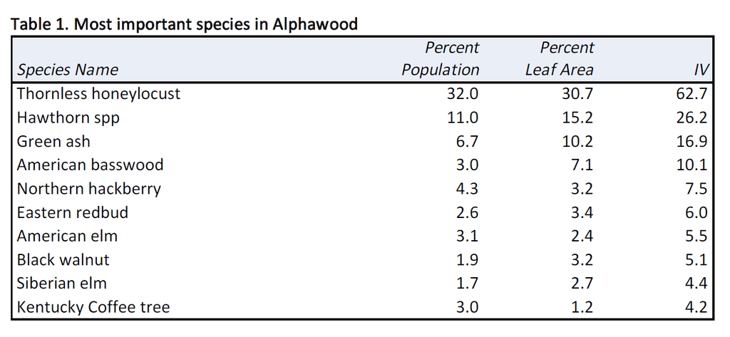

Table 3

*Table 3. Most important species in Alphawood by IV*

This importance metric does not indicate that a given species is more beneficial than another, but rather evaluates which species currently dominate the urban forest structure.

Pollution removal by trees was estimated using the field data and recent available pollution and weather data using the methods described earlier in the section. It is estimated that trees remove 1140 pounds of air pollution per year. The breakdown of how much of each main air pollutant was removed from the 1140-pound total is depicted below.

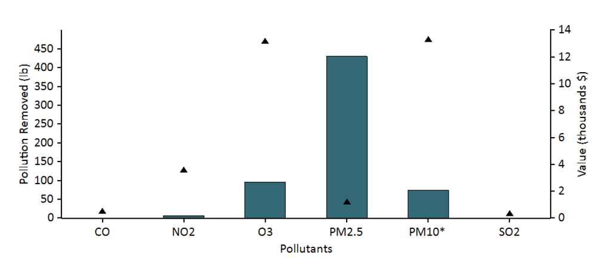

*Figure 9. Annual pollution removal (points) and value (bars) by urban trees*

Ozone (O3) and PM10 were the pollutants with the highest estimated removal rates, at above 450 pounds per year, respectively. PM2.5 removal was significantly lower than PM10, at around 50 pounds per year. The other side of the chart indicates that this lower removal rate is still worth an estimated value of $12,000. Although this report does not analyze cost in depth, this indicates that even a low removal rate of PM2.5 relative to the other main pollutants may still have desirable community impacts.

Trees reduce the amount of carbon in the atmosphere by sequestering carbon in new growth every year, and the amount of carbon annually sequestered increases with the size and health of the tree. Using the methods described earlier in the section, the i-Tree Eco model estimated the amount of annual carbon sequestration per species. Overall annual sequestration was estimated as approximately 14.86 tons of carbon per year. The per-species breakdown is given by Figure 10.

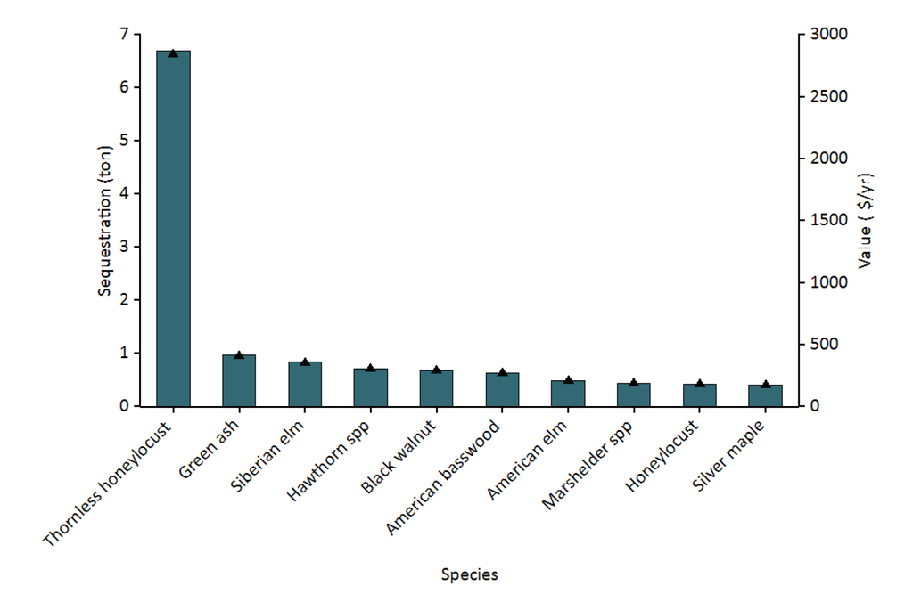

*Figure 10. Estimated annual gross carbon sequestration (points) and value (bars) for urban tree species*

Out of species, Thornless Honeylocust sequesters the most carbon per year. While making up 32.0% of trees in the arboretum, this estimate indicates that they sequester approximately 6.7 tons of carbon annually. Out of the 14.86 tons sequestered by all trees, Thornless Honeylocusts alone make up approximately 44.6% of all carbon sequestration, significantly more than their 32.0% share of the overall population. This could be due to a higher average DBH value for the species or a higher number of older Thornless Honeylocusts, since they would be closer to fully grown and have a higher DBH. Trees also store carbon long-term. As a tree grows, it stores more carbon in its accumulated tissue, and releases stored carbon back into the atmosphere as it dies and decays. Based on the techniques described earlier in the section, the i-Tree Eco model estimated that the trees in Alphawood store 1170 tons of carbon. The per-species breakdown of carbon storage is depicted in Figure 11.

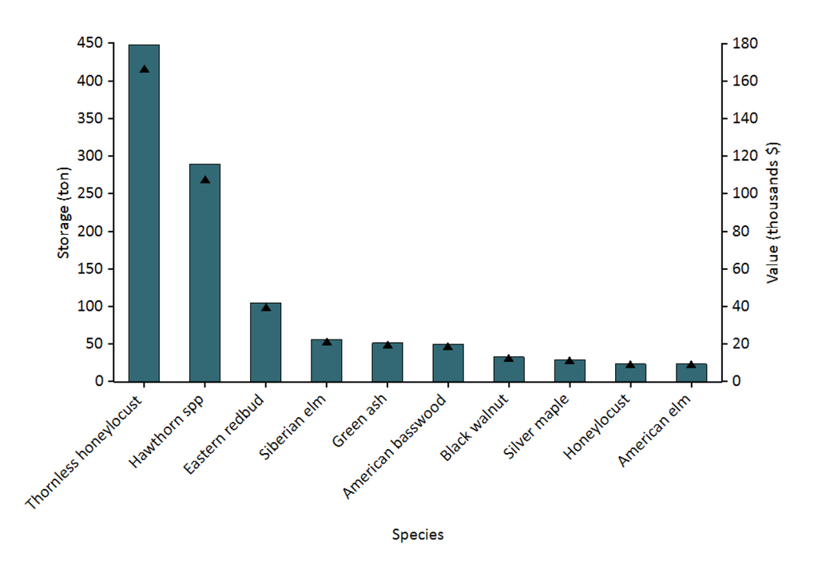

*Figure 11. Estimated carbon storage (points) and values (bars) for urban tree species*

Thornless honeylocusts also make up a large portion of carbon storage, at approximately 35.5% of all carbon stored. Compared to carbon sequestration, however, this portion is much closer to their 32.0% share of total trees on campus. However, this may be an overestimation, as the model could not account for decaying trees due to a lack of crown health measurements, which would lower overall carbon storage and sequestration.

The ecosystem service values and biodiversity indices together can functionally model the arboretum’s ecological contributions. Although also dependent on species, the canopy coverage of 25% (25.02 acres over 100 acres) is the foundational driver of carbon sequestration and storage, along with pollution removal. The per-acre pollution removal of 11.4 lb/acre/year and carbon sequestration of 0.15 tons/acre/year are broadly consistent with what 25% canopy coverage would be expected to produce, and align closely with Chicago’s citywide average of 12.0 lb/acre/year [18]. The $H’=2.98$ and $J’=0.68$. The values indicate that while the arboretum supports 77 species, the distribution is uneven: Thornless honeylocust’s 32% dominance compresses both indices below what a well-diversified arboretum might achieve. This has direct implications for ecosystem service resilience, as a forest with a single species accounting for a third of its canopy is more susceptible to pests [17].

It is important to note that this analysis alone cannot contribute to any species-specific conclusions. Its value as a tool for understanding human health outcomes remains constrained by the boundaries of a single-site, single-timepoint inventory. Calculating these values allows for a better understanding of the forest’s potential contributions to air quality and shade, which, based on the literature mentioned throughout this report, may have positive effects on physical and mental health. The objective of this analysis is to lay the groundwork for a future species-specific analysis. Expanding this methodology in two directions would substantially strengthen its health relevance. First, regular inventories at Alphawood would establish whether canopy coverage, species diversity, and ecosystem service outputs are improving or declining over time, allowing health-relevant metrics, such as PM2.5 removal, to be tracked as trends. Second, replicating the i-Tree Eco inventory framework across multiple Chicago arboreta, parks, and green spaces would generate the spatial coverage necessary to model how urban forest distribution correlates with neighborhood-level health outcomes, building on existing research linking tree canopy density to reduced stress, improved mental well-being, faster recovery from illness, and greater physical activity. Integrating i-Tree ecosystem service data with survey-based well-being measures or health outcome records at the neighborhood level would represent a meaningful methodological step toward closing that gap.

# 6. Conclusion

This study was guided by three interconnected research questions about Chicago’s urban forest. Canopy coverage does not significantly predict neighborhood health outcomes in Chicago after controlling for socioeconomic and environmental factors. Neighborhood-scale species data does not exist at a large scale in Chicago to test species-level hypotheses. The IIT Alphawood Arboretum case study laid the groundwork for future species-specific tree documentation and analysis.

The findings carry direct implications for community organizations that are active across Chicago. Neighborhoods in Chicago with the least canopy coverage and the worst health outcomes are geographically concentrated on the South and West sides, but causal relationships cannot be established at the citywide level yet. The species data gap is genuine and future investment into data infrastructure should be considered. The IIT Alphawood Arboretum is a useful case study that establishes a species-level benchmark and provides a proof-of-concept analysis for a neighborhood on Chicago’s South Side. The priority planting framework gives community organizations specific census tracts to target for planting. Community organizations should focus on compiling a Chicago wide species-level inventory, in order to better understand Chicago’s urban forest. Evidence-based species selection for health equity remains impossible at a citywide scale without it.

Equitable urban forestry in Chicago requires both investment in high-need neighborhoods and the data infrastructure to evaluate species-specific impacts. This study provides the first step toward both.

# 7. References

[1] Sicard, P., Pascu, I., Petrea, S. et al. (2025). Effect of tree canopy cover on air pollution-related mortality in European cities: an integrated approach. The Lancet Planetary Health, 9, e527–e537.

[2] McDonald, R.I., Biswas, T., Chakraborty, T.C. et al. (2024). Current inequality and future potential of US urban tree cover for reducing heat-related health impacts. npj Urban Sustainability, 4, 18. https://doi.org/10.1038/s42949-024-00150

[3] Astell-Burt, T., Navakatikyan, M.A., & Feng, X. (2023). Why might urban tree canopy reduce dementia risk? A causal mediation analysis of 109,688 adults with 11 years of hospital and mortality records. Health & Place, 82, 103028. https://doi.org/10.1016/j.healthplace.2023.103028

[4] Morton Arboretum. (2024). Benefits of Trees. Chicago Region Trees Initiative. https://mortonarb.org/plant-and-protect/benefits-of-trees

[5] Chicago Region Trees Initiative. (2024). Tree Equity: Legacy Impacts of Redlining on Canopy Cover. https://chicagorti.org/equity/#legacy-impacts-of-redlining-on-canopy-cover

[6] Nardone, A., Rudolph, K.E., Morello-Frosch, R., & Casey, J.A. (2021). Redlines and greenspace: The relationship between historical redlining and 2010 greenspace across the United States. Environmental Health Perspectives, 129(1), 017006. https://doi.org/10.1289/EHP7495

[7] Locke, D.H., Hall, B., Grove, J.M. et al. (2021). Residential housing segregation and urban tree canopy in 37 US cities. npj Urban Sustainability, 1, 15. https://doi.org/10.1038/s42949-021-00022-0

[8] Chicago Region Trees Initiative. (2024). Tree Equity: Overview. https://chicagorti.org/equity/#overview

[9] Morton Arboretum. (2024). Chicago Region Trees Initiative: Priority Maps – Tree Canopy. https://mortonarb.org/plant-and-protect/chicago-region-trees-initiative/priority-maps/#tree-canopy

[10] Nowak, D.J., Hoehn, R.E., Crane, D.E., Stevens, J.C., & Leblanc Fisher, C. (2010). Assessing urban forest effects and values: Chicago’s urban forest. Resource Bulletin NRS-37. U.S. Department of Agriculture, Forest Service, Northern Research Station.

[11] Tallamy, D.W., & Shropshire, K.J. (2009). Ranking lepidopteran use of native versus introduced plants. Conservation Biology, 23(4), 941–947. https://doi.org/10.1111/j.1523-1739.2009.01202.x

[12] Bratman, G.N. et al. (2019). Nature and mental health: An ecosystem service perspective. Science Advances, 5, eaax0903. https://doi.org/10.1126/sciadv.aax0903

[13] Lovasi, G.S., Quinn, J.W., Neckerman, K.M., Perzanowski, M.S., & Rundle, A. (2008). Children living in areas with more street trees have lower prevalence of asthma. Journal of Epidemiology and Community Health, 62(7), 647–649. https://doi.org/10.1136/jech.2007.071894

[14] Donovan, G.H., Butry, D.T., Michael, Y.L., Prestemon, J.P., Liebhold, A.M., Gatziolis, D., & Mao, M.Y. (2013). The relationship between trees and human health: Evidence from the spread of the emerald ash borer. American Journal of Preventive Medicine, 44(2), 139–145. https://doi.org/10.1016/j.amepre.2012.09.066

[15] Nowak, D.J., & Crane, D.E. (2002). Carbon storage and sequestration by urban trees in the USA. Environmental Pollution, 116(3), 381–389. https://doi.org/10.1016/S0269-7491(01)00214-7

[16] Nowak, D.J., & Crane, D.E. (2000). The Urban Forest Effects (UFORE) model: Quantifying urban forest structure and functions. In M. Hansen & T. Burk (Eds.), Integrated tools for natural resources inventories in the 21st century. Gen. Tech. Rep. NC-212 (pp. 714–720). U.S. Department of Agriculture, Forest Service, North Central Forest Experiment Station.

[17] Santamour, F.S. (1990). Trees for urban planting: Diversity, uniformity, and common sense. Proceedings of the 7th Conference of the Metropolitan Tree Improvement Alliance (METRIA), 7, 57–65.

[18] i-Tree. (2026). i-Tree Ecosystem Analysis: Alphawood Urban Forest Effects and Values. U.S. Forest Service, Northern Research Station.

[19] Sungmin Lee, Ryun Jung Lee, Sebastian Scherr, How tree canopy cover can reduce urban suicide attempts: A geospatial analysis of the moderating role of area deprivation, Landscape and Urban Planning, Volume 230, 2023, 104606, ISSN 0169-2046, https://doi.org/10.1016/j.landurbplan.2022.104606. (https://www.sciencedirect.com/science/article/pii/S0169204622002559)

[^1]: Contact the author.
[^2]: Contact the author.